Link to this document's Jupyter Notebook

In order to successfully complete this assignment you need to participate both individually and in groups during class. If you attend class in-person then have one of the instructors check your notebook and sign you out before leaving class. If you are attending asynchronously, turn in your assignment using D2L no later than *11:59pm on the day of class*. See links at the end of this document for access to the class timeline for your section.

In order to successfully complete this assignment you need to participate both individually and in groups during class. If you attend class in-person then have one of the instructors check your notebook and sign you out before leaving class. If you are attending asyncronously, turn in your assignment using D2L no later than *11:59pm on the day of class*. See links at the end of this document for access to the class timeline for your section.

# In-Class Assignment: The Kinematics of Robotics

[figure not shown]

Image from: https://pixabay.com/images/search/toy%20robot/

Today, we will calculate the forward kinematics of some 3D robots. This means we would like to come up with a set of transformations such that we can know the $x,~y,~z$ coordinates of the end effector with respect to the world coordinate system which is at the base of the robot.

### Agenda for today's class (80 minutes)

1. (20 minutes) Quiz Review
2. (30 minutes) Robot Kinematics - Pick and Place
3. (30 minutes) Odd_Clock

# 1. Quiz Review

Your instructor will use this time to go over the quiz from last week and answer any questions you have.

# 2. Pick and Place

Consider the robot depicted in the following image.

[figure not shown]

This style of robot is often called a "pick-and-place" robot. It has two motors that rotate around the z-axis to move the end effector in the $x-y$-plane; one "linear actuator" which moves up-and-down in the $z$-direction; and then finally a third rotating "wrist" joint that turns the "hand" of the robot. Let's model our robot using the following system diagram:

[figure not shown]

**NOTE:** The origin for this robot is located at the base of the first "tower" and is in-line with the first joint. The $x$-direction goes from the origin to the right and the $z$-axis goes from the origin upwards.

This is a little more tricky than the 2D case where everything was rotating around the axes that projects out of the $x-y$ plane.  
In 2D we only really worry about one axis of rotation. However in 3D we can rotate around the $x$, $y$, and $z$ axis. The following are the 3D transformation matrices that combine rotation and translations:

## X-Axis rotation

$$ \left[ \begin{matrix} x' \\ y' \\ z' \\ 1 \end{matrix} \right] = \left[ \begin{matrix} 1 & 0 & 0 & dx \\ 0 & cos(q) & -sin(q) & dy \\ 0 & sin(q) & cos(q) & dz \\ 0 & 0 & 0 & 1 \end{matrix} \right] \left[ \begin{matrix} x \\ y \\ z \\ 1 \end{matrix} \right] $$

## Y-Axis rotation

$$ \left[ \begin{matrix} x' \\ y' \\ z' \\ 1 \end{matrix} \right] = \left[ \begin{matrix} cos(q) & 0 & sin(q) & dx \\ 0 & 1 & 0 & dy \\ -sin(q) & 0 & cos(q) & dz \\ 0 & 0 & 0 & 1 \end{matrix} \right] \left[ \begin{matrix} x \\ y \\ z \\ 1 \end{matrix} \right] $$

## Z-Axis rotation

$$ \left[ \begin{matrix} x' \\ y' \\ z' \\ 1 \end{matrix} \right] = \left[ \begin{matrix} cos(q) & -sin(q) & 0 & dx \\ sin(q) & cos(q) & 0 & dy \\ 0 & 0 & 1 & dz \\ 0 & 0 & 0 & 1 \end{matrix} \right] \left[ \begin{matrix} x \\ y \\ z \\ 1 \end{matrix} \right] $$

**Question:** Construct a joint transformation matrix called $J_1$, which represents a coordinate system that is located at the top of the first "tower" (robot's sholder) and moves by rotating around the $z$-axis by $\theta_1$ degrees. Represent your matrix using `sympy` and the provided symbols:

```python
# Here are some libraries you may need to use
%matplotlib inline
import matplotlib.pylab as plt
import numpy as np
import sympy as sym
import math
sym.init_printing()
```

```python
#Use the following symbols

q1,q2,d4,q4,v1,v2,a1,a2 = sym.symbols('\Theta_1, \Theta_2, d_4, \Theta_4, V_1, V_2,A_1,A_2', negative=False)
```

```python
#put your answer here
q1
```

$\displaystyle \Theta_1$

**Question:** Construct a joint transformation matrix called $J_2$, which represents a coordinate system that is located at the "elbow" joint between the two rotating arms and rotates with the second arm around the $z$-axis by $\theta_2$ degrees. Represent your matrix using `sympy` and the symbols provided in question a:

```python
#put your answer here
```

**Question:** Construct a joint transformation matrix called $J_3$, which represents a coordinate translation from the "elbow" joint all the way to the horizontal end of the robot arm above the wrist joint. Note: there is no rotation in this transformation. Represent your matrix using `sympy` and the symbols provided in question a:

```python
#put your answer here
```

**Question:** Construct a joint transformation matrix called $J_4$, which represents a coordinate system that is located at the tip of the robot's "hand" and rotates around the $z$-axis by $\theta_4$. This one is a little different, the configuration is such that the hand touches the table when $d_4=0$ so the translation component for the matrix in the z axis is $d_4-V_1-V_2$.

```python
#put your answer here
```

**Question:** Rewrite the joint transformation matrices from questions a - d as numpy matrices with discrete (instead of symbolic) values. Plug in your transformations in the code below and use this to simulate the robot:

```python
from ipywidgets import interact
from mpl_toolkits.mplot3d import Axes3D

def Robot_Simulator(theta1=0,theta2=-0,d4=0,theta4=0):

    #Convert from degrees to radians
    q1 = theta1/180 * math.pi
    q2 = theta2/180 * math.pi
    q4 = theta4/180 * math.pi

    #Define robot geomitry
    V1 = 4
    V2 = 0
    A1 = 2
    A2 = 2

    #Define your transfomraiton matrices here.
    J1 = np.matrix([[1, 0, 0, 0 ],
                    [0, 1, 0, 0 ],
                    [0, 0, 1, 0],
                    [0, 0, 0, 1]])

    J2 = np.matrix([[1, 0, 0, 0 ],
                    [0, 1, 0, 0 ],
                    [0, 0, 1, 0],
                    [0, 0, 0, 1]])

    J3 = np.matrix([[1, 0, 0, 0 ],
                    [0, 1, 0, 0 ],
                    [0, 0, 1, 0],
                    [0, 0, 0, 1]])

    J4 = np.matrix([[1, 0, 0, 0 ],
                    [0, 1, 0, 0 ],
                    [0, 0, 1, 0],
                    [0, 0, 0, 1]])


    #Make the rigid end effector
    p = np.matrix([[-0.5,0,0, 1], [-0.5,0,0.5,1], [0.5,0,0.5, 1], [0.5,0,0,1],[0.5,0,0.5, 1], [0,0,0.5,1], [0,0,V1+V2,1]]).T

    #Propogate and add joint points though the simulation
    p = np.concatenate((J4*p, np.matrix([0,0,0,1]).T), axis=1 )
    p = np.concatenate((J3*p, np.matrix([0,0,0,1]).T), axis=1 )
    p = np.concatenate((J2*p, np.matrix([0,0,0,1]).T), axis=1 )
    p = np.concatenate((J1*p, np.matrix([0,0,0,1]).T), axis=1 )

    fig = plt.figure()
    ax = fig.add_subplot(111, projection='3d')

    ax.scatter(p[0,:].tolist()[0],(p[1,:]).tolist()[0], (p[2,:]).tolist()[0], s=20, facecolors='blue', edgecolors='r')
    ax.scatter(0,0,0, s=20, facecolors='r', edgecolors='r')
    ax.plot(p[0,:].tolist()[0],(p[1,:]).tolist()[0], (p[2,:]).tolist()[0])
    ax.set_xlim([-5,5])
    ax.set_ylim([-5,5])
    ax.set_zlim([0,6])
    ax.set_xlabel('x-axis')
    ax.set_ylabel('y-axis')
    ax.set_zlabel('z-axis')

    plt.show()

target = interact(Robot_Simulator, theta1=(-180,180), theta2=(-180,180), d4=(0,6), theta4=(-180,180)); ##TODO: Modify this line of code
```

✅ **Question:** Can we change the order of the transformation matrices? Why? You can try and see what happens.

Put your answer to the above question here.

# 3. Odd Clock

Consider the clock depicted in the following image.

[figure not shown]

from: [Hackaday](https://hackaday.com/2015/05/26/odd-clock-moves-minute-hand-to-hour-hand/)

Instead of a standard clock--which has independent hour and minute hands--this clock connects the minute hand at the end of the hour hand. Here is a video showing the sped-up clock motion:

```python
from IPython.display import YouTubeVideo
YouTubeVideo("bowLiSlm_gA",width=640,height=360, mute=1)
```

[video not shown]

The following code is an animated traditional clock which uses the function as a trick to animate things in jupyter:

```python
%matplotlib inline
import matplotlib.pylab as plt
from IPython.display import display, clear_output
import time
def show_animation(delay=0.01):
    fig = plt.gcf();
    time.sleep(delay)       # Sleep for half a second to slow down the animation
    clear_output(wait=True) # Clear output for dynamic display
    display(fig)            # Reset display
    fig.clear()             # Prevent overlapping and layered plots
```

Lets see a standard analog clock run at high speed

```python
import numpy as np
'''
Analog clock plotter with time input as seconds
'''
def analog_clock(tm=0):

    #Convert from time to radians
    a_minutes = -tm/(60*60) * np.pi * 2
    a_hours = -tm/(60*60*12) * np.pi * 2

    #Define clock hand sizees
    d_minutes = 4
    d_hours = 3
    arrow_width=0.5
    arrow_length=1

    # Set up figure
    fig = plt.gcf()
    ax = fig.gca();
    ax.set_xlim([-15,15]);
    ax.set_ylim([-10,10]);
    ax.scatter(0,0, s=15000, color="navy"); #Background Circle
    plt.axis('off');

    # Calculation Minute hand transformation matrix
    J2 = np.matrix([[np.cos(a_minutes), -np.sin(a_minutes)],
                    [np.sin(a_minutes), np.cos(a_minutes)]] )
    pm = np.matrix([[0,d_minutes], [-arrow_width,d_minutes], [0,arrow_length+d_minutes], [arrow_width,d_minutes], [0,d_minutes]] ).T;
    pm = np.concatenate((J2*pm, np.matrix([0,0]).T), axis=1 );
    ax.plot(pm[0,:].tolist()[0],(pm[1,:]).tolist()[0], color='cyan', linewidth=2);

    # Calculation Hour hand transformation matrix
    J1 = np.matrix([[np.cos(a_hours), -np.sin(a_hours)],
                    [np.sin(a_hours), np.cos(a_hours)]] )
    ph = np.matrix([[0,d_hours], [0,d_hours], [-arrow_width,d_hours], [0,arrow_length+d_hours], [arrow_width,d_hours], [0,d_hours]]).T;
    ph = np.concatenate((J1*ph, np.matrix([0,0]).T), axis=1 );
    ax.plot(ph[0,:].tolist()[0],(ph[1,:]).tolist()[0], color='yellow', linewidth=2);
```

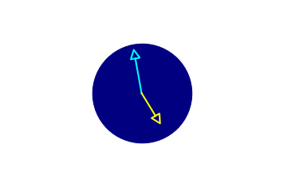

```python
#Run the clock for about 5 hours at 100 times speed so we can see the hands move
for tm in range(0,60*60*5, 100):
    analog_clock(tm);
    show_animation();
```

For the following few questions, consider the transformation matrix $J_1$ redefined below with an angle of 5 hours out of 12.

```python
import sympy as sym
import numpy as np
sym.init_printing(use_unicode=True)

a_hours = 5/12 * 2 * np.pi
J1 = np.matrix([[np.cos(a_hours), -np.sin(a_hours)],
                [np.sin(a_hours), np.cos(a_hours)]] )

sym.Matrix(J1)
```

$\displaystyle \left[\begin{matrix}-0.866025403784439 & -0.5\\0.5 & -0.866025403784439\end{matrix}\right]$

✅ **Question:** Using code, show that the transpose of $J_1$ is also the inverse of $J_1$, then explain how the code demonstrates the answer.

```python
#Put your answer here
```

**Explain your answer here.**

✅ **Question:** Given the trigonometric identity $cos^2(\theta) + sin^2(\theta) = 1$, prove by construction--using either Python or $\LaTeX$/`Markdown` or `sympy` (if you are feeling adventurous)--that the transpose of the $J_1$ matrix is also the inverse for ANY angle `a_hours` $\in [0, 2\pi]$.

**Put your prof here.**

Now consider the following code which attempts to connect the hands on the clock together to make the Odd Clock shown in the video above.

```python
%matplotlib inline
import matplotlib.pylab as plt
from IPython.display import display, clear_output
import time
def show_animation(delay=0.01):
    fig = plt.gcf();
    time.sleep(delay)       # Sleep for half a second to slow down the animation
    clear_output(wait=True) # Clear output for dynamic display
    display(fig)            # Reset display
    fig.clear()             # Prevent overlapping and layered plots
```

```python
import numpy as np

def odd_clock(tm=0):

    #Convert from time to radians
    #a_seconds = -tm/60 * np.pi * 2
    a_minutes = -tm/(60*60) * np.pi * 2
    a_hours = -tm/(60*60*12) * np.pi * 2

    #Define robot geomitry
    #d_seconds = 2.5
    d_minutes = 2
    d_hours = 1.5
    arrow_width=0.5
    arrow_length=1

    # Set up figure
    fig = plt.gcf()
    ax = fig.gca();
    ax.set_xlim([-15,15]);
    ax.set_ylim([-10,10]);
    plt.axis('off');

    #Define the arrow at the end of the last hand
    #p = np.matrix([[0,d_minutes,1], [0,0,1]]).T
    p = np.matrix([[0,d_minutes,1], [-arrow_width,d_minutes,1], [0,arrow_length+d_minutes,1], [arrow_width,d_minutes,1 ], [0,d_minutes,1 ], [0,0,1]] ).T;

    # Calculation Second hand transformation matrix
    J2 = np.matrix([[np.cos(a_minutes), -np.sin(a_minutes), 0 ],
                    [np.sin(a_minutes), np.cos(a_minutes), d_hours ],
                    [0, 0, 1]])
    p = np.concatenate((J2*p, np.matrix([0,0,1]).T), axis=1 )

    J1 = np.matrix([[np.cos(a_hours), -np.sin(a_hours), 0 ],
                    [np.sin(a_hours), np.cos(a_hours), 0 ],
                    [0, 0, 1]])
    p = np.concatenate((J1*p, np.matrix([0,0,1]).T), axis=1 )

    ax.scatter(0,0, s=20, facecolors='r', edgecolors='r')
    ax.plot(p[0,:].tolist()[0],(p[1,:]).tolist()[0])
```

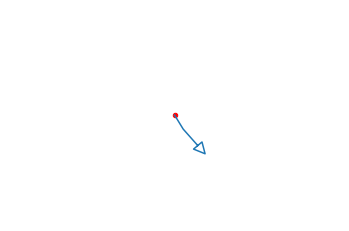

```python
#Run the clock for about 5 hours at 100 times speed so we can see the hands move
for tm in range(0,60*60*5, 100):
    odd_clock(tm);
    show_animation();
```

✅ **Question:** Using the given point ($p$) written in "minutes" coordinates (**on line 26 of the above code**) and the above transformation matrices ($J_1,J_2$), write down the equation to transform $p$ into world coordinates $p_w$.

**Put the answer to the above question here**

### Congratulations, we're done!

If you attend class in-person then have one of the instructors check your notebook and sign you out before leaving class. If you are attending asynchronously, turn in your assignment using D2L.

### Course Resources:

- [MTH314 Course Website](http://cmse.msu.edu/mth314)

Written by Dr. Dirk Colbry, Michigan State University  
This work is licensed under a [Creative Commons Attribution-NonCommercial 4.0 International License](http://creativecommons.org/licenses/by-nc/4.0/).